# Data Analysis for stress & coping on Academic performance

# Academic Success or Failure: What Patterns Can Be Identified?

- Clustering Analysis: Grouping Students Based on Performance & Stress

```r
library(cluster)
scaled_data <- scale(data_cleaned[, c("GPA", "Stress_levels", "frequency_of_coping")])
kmeans_result <- kmeans(scaled_data, centers = 3)

data_cleaned$Cluster <- as.factor(kmeans_result$cluster)
table(data_cleaned$Cluster)
```

```
##
##  1  2  3
## 28 13 11
```

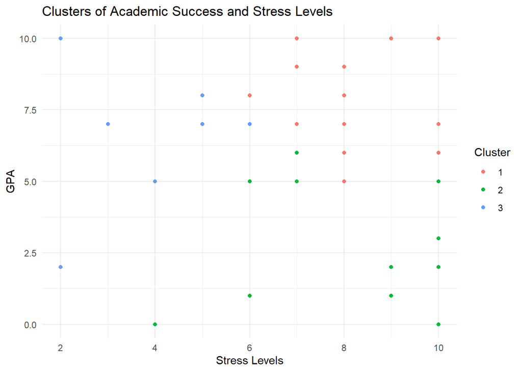

```r
ggplot(data_cleaned, aes(x = Stress_levels, y = GPA, color = Cluster)) +
  geom_point() +
  labs(title = "Clusters of Academic Success and Stress Levels", x = "Stress Levels", y = "GPA") +
  theme_minimal()
```

## **Findings and Insights**

1️⃣ Family Structure and Its Impact on GPA and Stress The ANOVA results suggest:

- GPA is not significantly affected by family structure (p = 0.474). This means that students from single-parent, dual-parent, or extended-family households do not show major differences in academic performance.
- Stress levels are also not significantly different across family structures (p = 0.662). This indicates that regardless of family structure, students report similar levels of stress.
- The boxplots visually confirm that there is no clear trend—GPA and stress levels appear to be distributed similarly across different family structures.

> 📌 Key Insight: Family structure does not play a strong role in determining GPA or stress, suggesting that other factors (like personal resilience or support systems) may have a greater impact.

2️⃣ Educational Level and Its Effect on Stress & Coping Strategies The average stress level varies slightly across different parental education levels. Students whose parents have no formal education or only primary education tend to report higher stress levels, while those whose parents have secondary or higher education report lower stress levels.

- However, the ANOVA results show no significant difference in stress levels (p = 0.775) or coping frequency (p = 0.474) based on parental education.
- The boxplots illustrate that students from all education backgrounds show similar distributions of stress and coping strategies, confirming the statistical results.

> 📌 Key Insight: While parental education level may influence students’ perceived stress, it does not statistically determine their stress levels or coping mechanisms.

3️⃣ Access to Digital Resources and Academic Performance - The mean GPA is highest for students with “Good” or “Limited” access, while students with “Excellent” or “Moderate” access have slightly lower GPAs.

- The ANOVA test (p = 0.543) shows no significant difference in GPA based on digital access levels.
- The boxplot confirms that GPA values are distributed similarly across different levels of digital access, with no clear advantage for students with excellent digital resources.

> 📌 Key Insight: Having better digital access does not necessarily guarantee higher academic performance. This suggests that other factors (e.g., study habits, instructional quality, or personal effort) might play a more crucial role.

4️⃣ Academic Success or Failure: Clustering Students by Stress and Performance The k-means clustering grouped students into 3 clusters based on their GPA, stress levels, and coping frequency.

> 📌 Key Insight: There are distinct patterns in how students experience stress and cope with academic challenges, suggesting that stress-coping strategies could be a key factor in academic success or failure rather than external circumstances like family background or digital access.